# Lab 2

Ryan Pate

2/19/2021

**We will be exploring what aspects of the chocolates may affect taste. Before setting off to the exploration, answer the following questions.**

1. How are the ratings distributed? Create both a histogram and a boxplot and describe them. Don’t forget to mention outliers, if there are any.

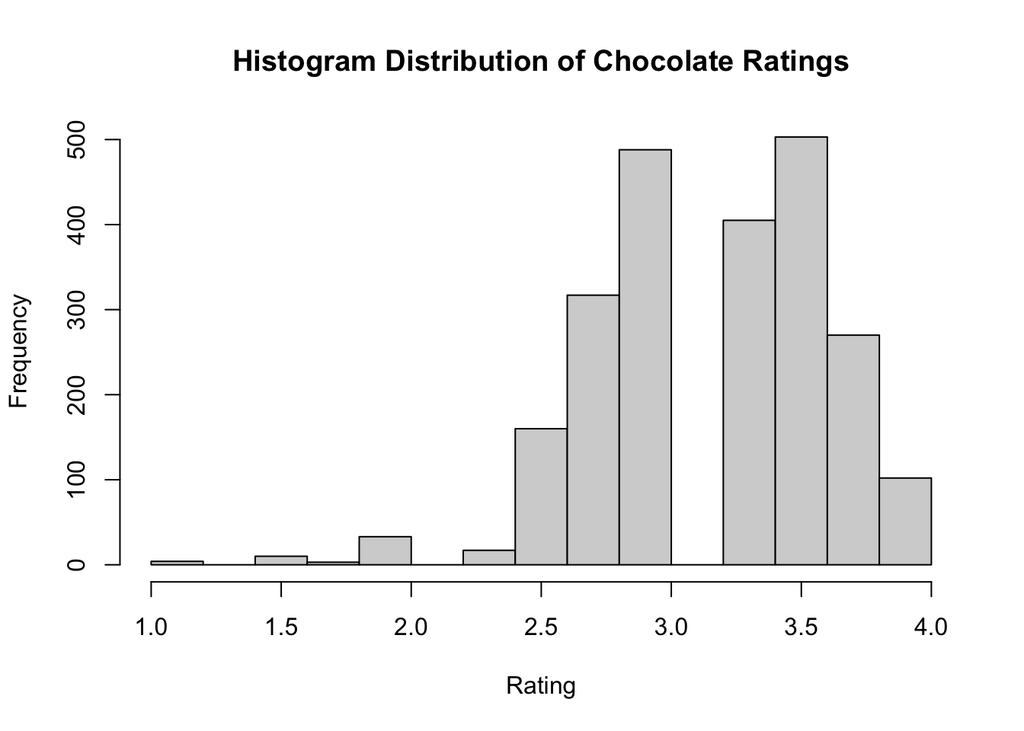

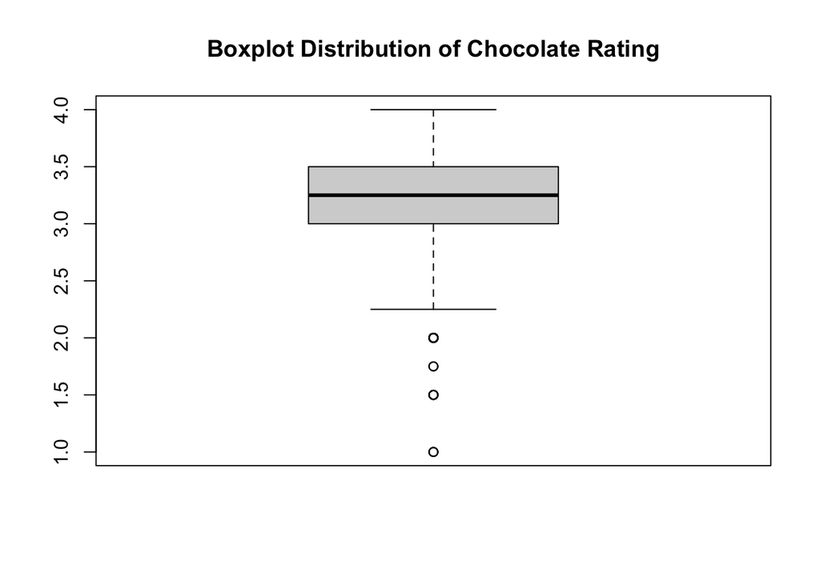

2. How does the number of ratings depend on the location of the company? Draw a bar chart of the number of reports.

   As you can see, I tried a couple of different ways to create a bar chart. Since there are so many locations I don’t feel that a bar chart is a good way of representing this data. I’m confused as to why the graph is showing a height from 0 to 3000 when it’s supposed to be displaying data on a rating scale from 0-4.

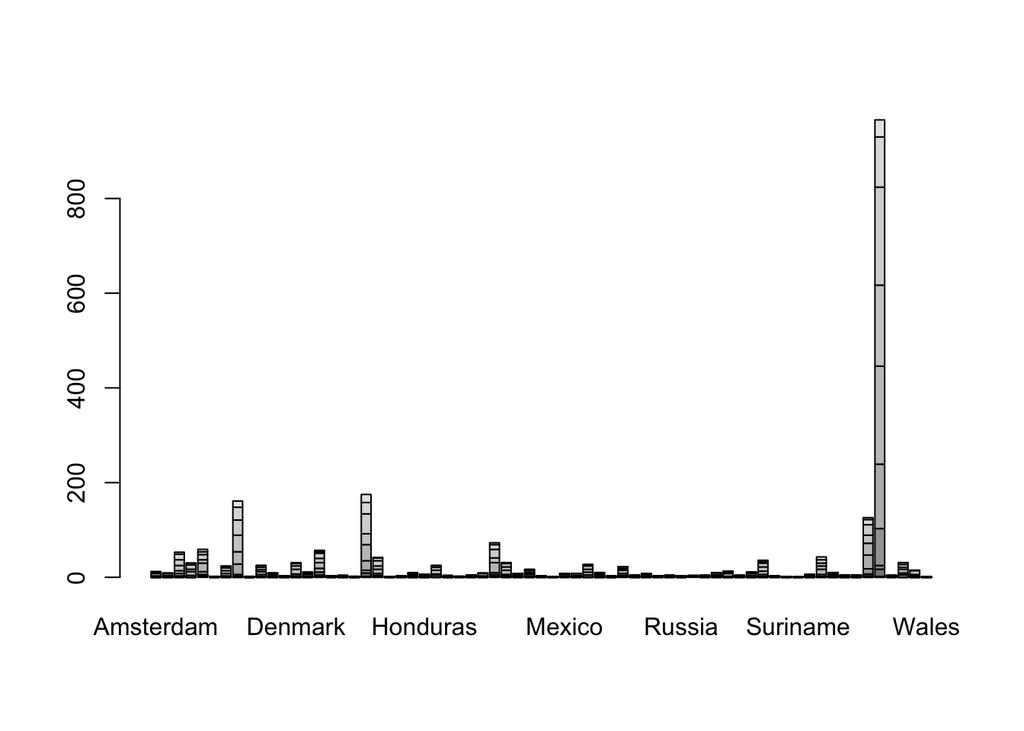

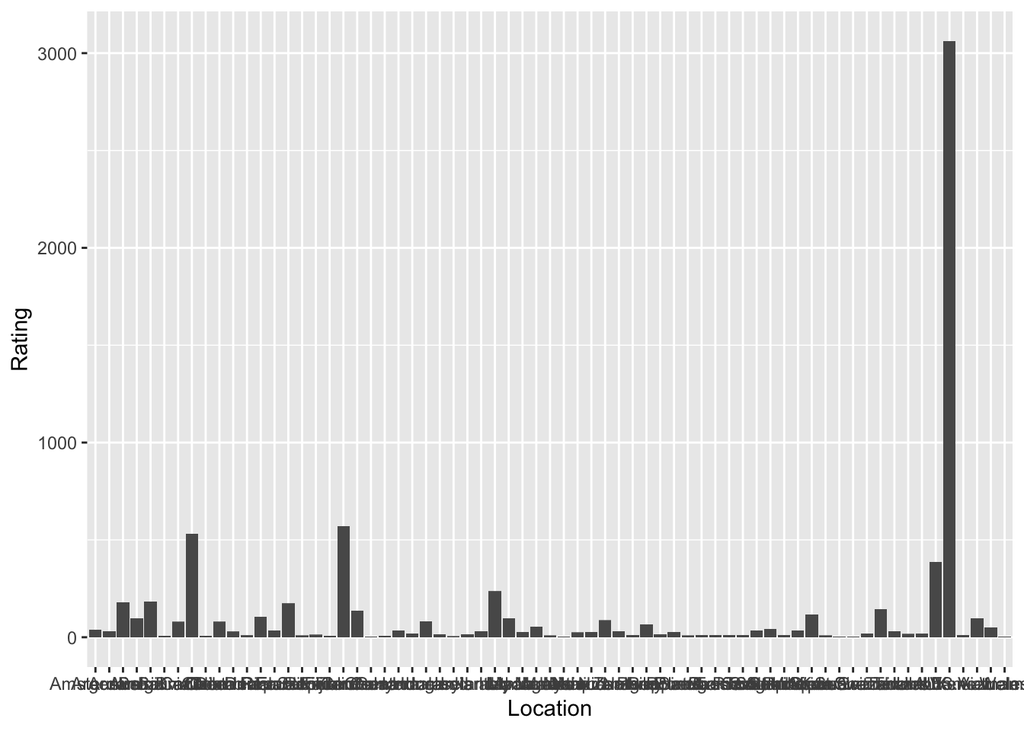

3. Do ratings depend on the cacao percentage of a chocolate bar? Create both numerical and graphical summaries, and explain. [Hint: Think about why the scatterplot is not a very good choice for visualization here.]